# Assignment Part 1

## 1. Import Libraries/Dataset

```python
import pandas as pd
import numpy as np
import seaborn as sns
import matplotlib.pyplot as plt
import warnings
warnings.filterwarnings('ignore')
%matplotlib inline
from google.colab import drive
drive.mount('/content/drive')
```

## 2. Data Visualization and Exploration

### 2.a. Sanity check to identify all the features present in the dataset and if the target matches with them.

```python
dataset = pd.read_csv('/content/drive/My Drive/Python 0/assignment/data_FinancialTransactions.csv')
#a.	Print 2 rows for sanity check
print("Sanity Check: First 2 Rows")
dataset.head(2)
```

```
Sanity Check: First 2 Rows
```

|  | Unnamed: 0 | Amount | Date | Card Type | MCC Category | Location | Device | Previous Transactions | Balance Before Transaction | Time of Day | Velocity | Customer Age | Customer Income | Card Limit | Credit Score | Merchant Reputation | Merchant Location History | Spending Patterns | Online Transactions Frequency | Is Fraudulent |
| --- | --- | --- | --- | --- | --- | --- | --- | --- | --- | --- | --- | --- | --- | --- | --- | --- | --- | --- | --- | --- |
| 0 | 0 | 180.924993 | 2023-07-02 | Debit | Electronics | UK | Desktop | 6 | 919.055267 | 10 | -0.337955 | 52 | 105545.340543 | 2503.758986 | 401 | Average | 6 | 828.820298 | Medium | 0 |
| 1 | 1 | 794.625797 | 2023-02-18 | Prepaid | Groceries | Canada | Desktop | 5 | 3529.930762 | 17 | 0.015117 | 62 | 92651.854405 | 12885.681726 | 409 | Average | 13 | 4384.528307 | Low | 1 |

```python
# Checking the dataset entries rows and columns size
dataset.info()
dataset.shape

#(dataset.loc[0:1, 'Amount':'Date']
#dataset.iloc[:5, 1:6]
```

```
<class 'pandas.core.frame.DataFrame'>
RangeIndex: 1000 entries, 0 to 999
Data columns (total 20 columns):
 #   Column                         Non-Null Count  Dtype
---  ------                         --------------  -----
 0   Unnamed: 0                     1000 non-null   int64
 1   Amount                         1000 non-null   float64
 2   Date                           1000 non-null   object
 3   Card Type                      1000 non-null   object
 4   MCC Category                   1000 non-null   object
 5   Location                       1000 non-null   object
 6   Device                         1000 non-null   object
 7   Previous Transactions          1000 non-null   int64
 8   Balance Before Transaction     1000 non-null   float64
 9   Time of Day                    1000 non-null   int64
 10  Velocity                       1000 non-null   float64
 11  Customer Age                   1000 non-null   int64
 12  Customer Income                1000 non-null   float64
 13  Card Limit                     1000 non-null   float64
 14  Credit Score                   1000 non-null   int64
 15  Merchant Reputation            1000 non-null   object
 16  Merchant Location History      1000 non-null   int64
 17  Spending Patterns              1000 non-null   float64
 18  Online Transactions Frequency  1000 non-null   object
 19  Is Fraudulent                  1000 non-null   int64
dtypes: float64(6), int64(7), object(7)
memory usage: 156.4+ KB
```

```
(1000, 20)
```

- Total 1000 rows of samples available in dataset
- Total 20 columns i.e., 19 independent features and 1 dependent feature (Is Fraudulent) in dataset
- Dataset contains multiple datatypes such as float, int, object values. Date coloumn is also provided with object datatype.

```python
# Quick look at columns
dataset.columns
```

```
Index(['Unnamed: 0', 'Amount', 'Date', 'Card Type', 'MCC Category', 'Location',
       'Device', 'Previous Transactions', 'Balance Before Transaction',
       'Time of Day', 'Velocity', 'Customer Age', 'Customer Income',
       'Card Limit', 'Credit Score', 'Merchant Reputation',
       'Merchant Location History', 'Spending Patterns',
       'Online Transactions Frequency', 'Is Fraudulent'],
      dtype='object')
```

```python
dataset.nunique()
```

|  | 0 |
| --- | --- |
| Unnamed: 0 | 1000 |
| Amount | 1000 |
| Date | 340 |
| Card Type | 3 |
| MCC Category | 7 |
| Location | 5 |
| Device | 3 |
| Previous Transactions | 10 |
| Balance Before Transaction | 1000 |
| Time of Day | 24 |
| Velocity | 1000 |
| Customer Age | 60 |
| Customer Income | 1000 |
| Card Limit | 1000 |
| Credit Score | 465 |
| Merchant Reputation | 3 |
| Merchant Location History | 19 |
| Spending Patterns | 1000 |
| Online Transactions Frequency | 3 |
| Is Fraudulent | 2 |

**dtype:** int64

- The columns Amount, Balance Before Transaction, Velocity, Customer Income, Card Limit, Spending Patterns have all unique values.
- Time of the day column represents the hour of the day i.e., all 24 hrs are included in dataset.

```python
dataset.describe(include='number')
```

|  | Unnamed: 0 | Amount | Previous Transactions | Balance Before Transaction | Time of Day | Velocity | Customer Age | Customer Income | Card Limit | Credit Score | Merchant Location History | Spending Patterns | Is Fraudulent |
| --- | --- | --- | --- | --- | --- | --- | --- | --- | --- | --- | --- | --- | --- |
| count | 1000.000000 | 1000.000000 | 1000.000000 | 1000.000000 | 1000.000000 | 1000.000000 | 1000.000000 | 1000.000000 | 1000.000000 | 1000.0000 | 1000.000000 | 1000.000000 | 1000.000000 |
| mean | 499.500000 | 520.177431 | 4.399000 | 4975.500335 | 11.425000 | 0.000316 | 49.432000 | 82963.616616 | 10474.007101 | 575.5080 | 9.754000 | 2746.678736 | 0.053000 |
| std | 288.819436 | 279.342434 | 2.828745 | 2841.249947 | 6.834697 | 0.296206 | 17.332853 | 37021.434932 | 5734.063838 | 156.4581 | 5.395238 | 1311.365916 | 0.224146 |
| min | 0.000000 | 10.456991 | 0.000000 | 123.460877 | 0.000000 | -0.499891 | 20.000000 | 20084.715403 | 526.910912 | 300.0000 | 1.000000 | 500.559090 | 0.000000 |
| 25% | 249.750000 | 277.978547 | 2.000000 | 2435.129681 | 5.000000 | -0.256706 | 35.000000 | 51725.434929 | 5287.512915 | 441.5000 | 5.000000 | 1561.576868 | 0.000000 |
| 50% | 499.500000 | 546.816714 | 4.000000 | 4794.595477 | 11.000000 | -0.011424 | 50.000000 | 81693.952416 | 10569.195493 | 574.5000 | 10.000000 | 2839.222191 | 0.000000 |
| 75% | 749.250000 | 760.074571 | 7.000000 | 7384.965602 | 17.000000 | 0.277094 | 64.000000 | 113430.363544 | 15474.888341 | 715.5000 | 14.000000 | 3860.482775 | 0.000000 |
| max | 999.000000 | 996.689893 | 9.000000 | 9975.859154 | 23.000000 | 0.499943 | 79.000000 | 149895.777624 | 19978.439668 | 849.0000 | 19.000000 | 4994.352225 | 1.000000 |

- Maximum Amount involved in a transaction is 996.689893 and Minimum Amount is 10.456991.
- Customer Age is ranging from 20 to 79 years old.
- Customer Income is ranging from 20084.715403 to 149895.777624, seems a lot of variation.
- The minimum value of Previous Transactions is 0 i.e., atleast one or more transactions in dataset have no previous transaction records.

```python
dataset.describe(include='object')
```

|  | Date | Card Type | MCC Category | Location | Device | Merchant Reputation | Online Transactions Frequency |
| --- | --- | --- | --- | --- | --- | --- | --- |
| count | 1000 | 1000 | 1000 | 1000 | 1000 | 1000 | 1000 |
| unique | 340 | 3 | 7 | 5 | 3 | 3 | 3 |
| top | 2023-08-27 | Credit | Travel | US | Desktop | Bad | Medium |
| freq | 10 | 353 | 166 | 224 | 341 | 350 | 343 |

- Surprisingly, most of (35%) merchant reputation shows as Bad.
- Most of the customers located is U.S.
- 34.1% transactions happened on Desktop device.
- 35.3% of the transactions made by Credit card type.
- The maximum transactions happend on 2023-08-27 date.

### 2.b. Data visualizations to get an insight about the dataset.

```
Class-1 represents fraudulent transactions
Class-0 represents legitimate transactions
Is Fraudulent
0    947
1     53
Name: count, dtype: int64
Percentage of fraudulent transactions: 5.3%
Percentage of legitimate transactions: 94.69999999999999%
```

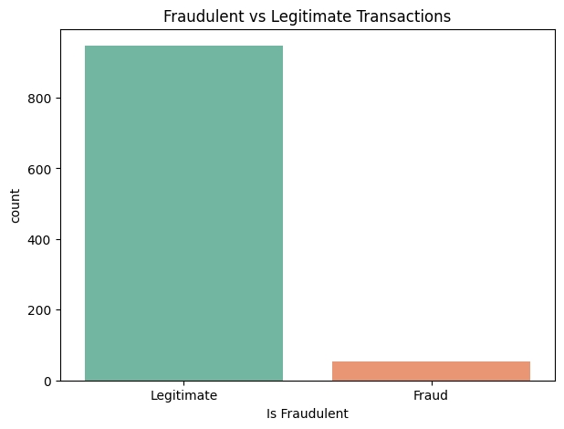

```python
# b. Data Visualizations

# Printing the values of Fraudulent vs Legitimate Transactions
print("Class-1 represents fraudulent transactions")
print("Class-0 represents legitimate transactions")
print(dataset['Is Fraudulent'].value_counts())

fraud = dataset[dataset['Is Fraudulent'] == 1]
legit = dataset[dataset['Is Fraudulent'] == 0]

print(f"Percentage of fraudulent transactions: {(len(fraud)/len(dataset))*100}%")
print(f"Percentage of legitimate transactions: {(len(legit)/len(dataset))*100}%")

plt.figure(figsize=(7, 5))
sns.countplot(x='Is Fraudulent', data=dataset, palette='Set2')
plt.title("Fraudulent vs Legitimate Transactions")
plt.xticks([0, 1], ["Legitimate", "Fraud"])
plt.show()
```

- The dataset contains transaction details, including amount, date, card type merchant category, location, and other financial attributes.
- The target variable is "*Is Fraudulent*" (1 for fraud, 0 for legitimate).
- There is an unnamed column (Unnamed: 0), which is an index and can be removed.

#### Understanding the distribution of data using multiple plots

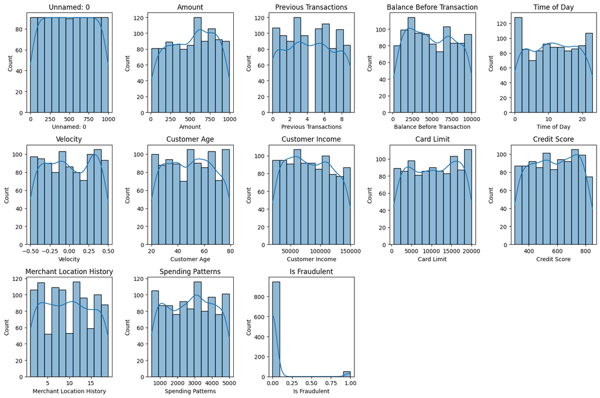

```python
# Understand the Distribution of data using histogram plot

numerical_features = dataset.select_dtypes(include=["number"]).columns

plt.figure(figsize=(15, 10))
for i, feature in enumerate(numerical_features, 1):
    plt.subplot(3, 5, i)
    sns.histplot(dataset[feature], kde=True)
    plt.title(feature)
plt.tight_layout()
plt.show()
```

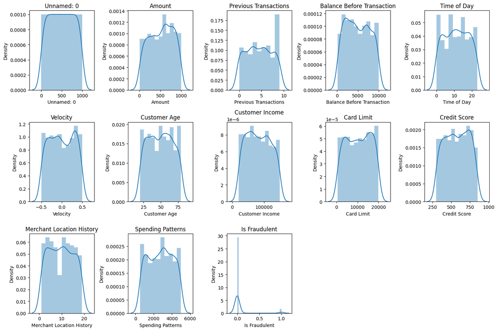

```python
# Understand the Distribution of data using distribution plot

numerical_features = dataset.select_dtypes(include=["number"]).columns

plt.figure(figsize=(15, 10))
for i, feature in enumerate(numerical_features, 1):
    plt.subplot(3, 5, i)
    sns.distplot(dataset[feature], kde=True)
    plt.title(feature)
plt.tight_layout()
plt.show()
```

- There is no significant skewness for any numerical data.

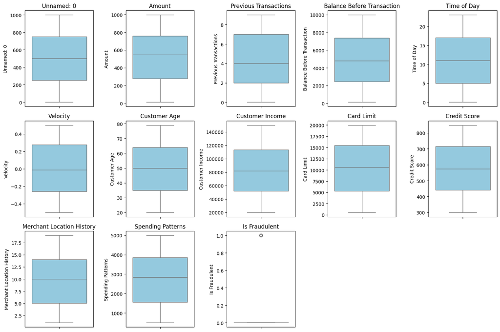

```python
# Understand the outliers existence using boxplot
numerical_features = dataset.select_dtypes(include=["number"]).columns

plt.figure(figsize=(15, 10))
for i, feature in enumerate(numerical_features, 1):
    plt.subplot(3, 5, i)
    sns.boxplot(y=dataset[feature], color="skyblue")
    plt.title(feature)
plt.tight_layout()
plt.show()
```

- It seems no outliers found for any numerical columns.

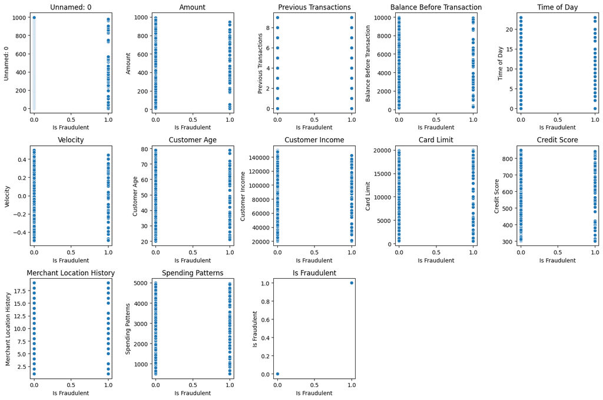

```python
# Understand the outliers existence using scatter plot
numerical_features = dataset.select_dtypes(include=["number"]).columns

plt.figure(figsize=(15, 10))
for i, feature in enumerate(numerical_features, 1):
    plt.subplot(3, 5, i)
    sns.scatterplot(data=dataset, y=feature, x="Is Fraudulent")
    plt.title(feature)
plt.tight_layout()
plt.show()
```

- The fraud transaction can be seen in all variables data.

### 2.c. Correlational analysis on the dataset

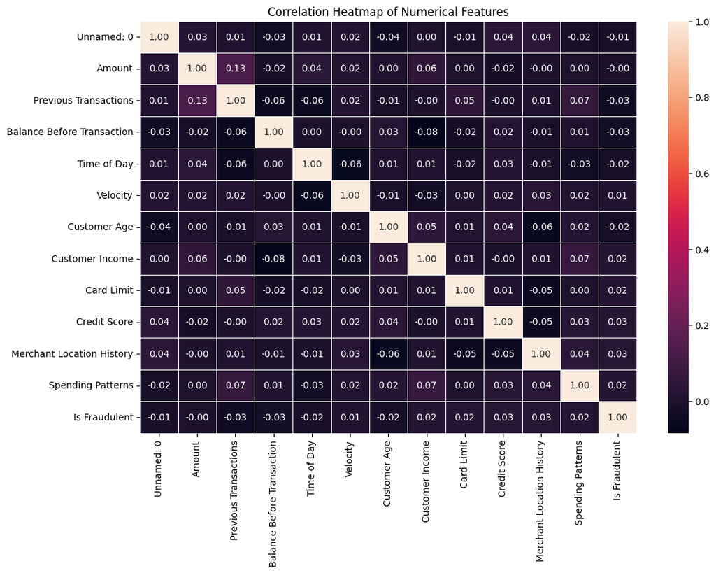

```python
numerical_features = dataset.select_dtypes(include=["number"])

# Plot correlation heatmap
plt.figure(figsize=(12, 8))
sns.heatmap(numerical_features.corr(), annot=True, fmt=".2f", linewidths=0.5)
plt.title("Correlation Heatmap of Numerical Features")
plt.show()
```

Impact on feature selection:

- As seen in the heatmap, most features have very low correlation with "Is Fraudulent" variable. However, low correlation does not always mean a feature is useless — Some features might have a non-linear relationship with fraud, which correlation analysis cannot detect.
- If two independent features are highly correlated, we can drop one of them to avoid redundancy.
- But the correlations among independent features are also weak, so we don’t have major multicollinearity concerns here.
- Correlation only captures linear relationships. Fraud detection can be complex and nonlinear, requiring techniques beyond correlation analysis.

## 3. Data Pre-processing and cleaning

### 3.a. Handling Missing values and Outliers

```python
# Identifying missing values
missing_values = dataset.isnull().sum()
print("Missing Values in Dataset:\n", missing_values)
```

```
Missing Values in Dataset:
 Unnamed: 0                       0
Amount                           0
Date                             0
Card Type                        0
MCC Category                     0
Location                         0
Device                           0
Previous Transactions            0
Balance Before Transaction       0
Time of Day                      0
Velocity                         0
Customer Age                     0
Customer Income                  0
Card Limit                       0
Credit Score                     0
Merchant Reputation              0
Merchant Location History        0
Spending Patterns                0
Online Transactions Frequency    0
Is Fraudulent                    0
dtype: int64
```

```python
# Handling Outliers using IQR method
numerical_features = dataset.select_dtypes(include=["number"])

Q1 = numerical_features.quantile(0.25)
Q3 = numerical_features.quantile(0.75)
IQR = Q3 - Q1
outliers = ((numerical_features < (Q1 - 1.5 * IQR)) | (numerical_features > (Q3 + 1.5 * IQR))).sum()
print("Outliers Count:\n", outliers)
```

```
Outliers Count:
 Unnamed: 0                     0
Amount                         0
Previous Transactions          0
Balance Before Transaction     0
Time of Day                    0
Velocity                       0
Customer Age                   0
Customer Income                0
Card Limit                     0
Credit Score                   0
Merchant Location History      0
Spending Patterns              0
Is Fraudulent                 53
dtype: int64
```

- Verified the dataset to identify null or missing using *isnull()* method
- Verified the dataset to identify the outliers using IQR formulas and also plotted the figure using boxplot.
- There are no outliers detected and also there are no null or missing values in dataset.

### 3.b. Feature Engineering and Transformations

- Removing unnecessary columns Unnamed and Date columns.

```python
# Removing unnecessary columns
dataset.drop(columns=['Unnamed: 0'], inplace=True)
dataset.drop(columns=['Date'], inplace=True)
```

- Convert datatypes for categorial columns

```python
# Datatype Conversion for categorial columns
for col in dataset.select_dtypes(include=["object"]).columns:
    dataset[col] = dataset[col].astype('category')

dataset.info()
```

```
<class 'pandas.core.frame.DataFrame'>
RangeIndex: 1000 entries, 0 to 999
Data columns (total 18 columns):
 #   Column                         Non-Null Count  Dtype
---  ------                         --------------  -----
 0   Amount                         1000 non-null   float64
 1   Card Type                      1000 non-null   category
 2   MCC Category                   1000 non-null   category
 3   Location                       1000 non-null   category
 4   Device                         1000 non-null   category
 5   Previous Transactions          1000 non-null   int64
 6   Balance Before Transaction     1000 non-null   float64
 7   Time of Day                    1000 non-null   int64
 8   Velocity                       1000 non-null   float64
 9   Customer Age                   1000 non-null   int64
 10  Customer Income                1000 non-null   float64
 11  Card Limit                     1000 non-null   float64
 12  Credit Score                   1000 non-null   int64
 13  Merchant Reputation            1000 non-null   category
 14  Merchant Location History      1000 non-null   int64
 15  Spending Patterns              1000 non-null   float64
 16  Online Transactions Frequency  1000 non-null   category
 17  Is Fraudulent                  1000 non-null   int64
dtypes: category(6), float64(6), int64(6)
memory usage: 100.8 KB
```

#### 3.b.(i). Feature Creation

Extracting a feature called Balance After Transacation with a logic to check if there is any significant change in balance as there could be a possibility that the transaction is fraud.

```python
dataset['Balance After Transaction'] = dataset['Balance Before Transaction'] - dataset['Amount']
```

```python
dataset['Balance After Transaction'].describe()
```

|  | Balance After Transaction |
| --- | --- |
| count | 1000.000000 |
| mean | 4455.322904 |
| std | 2860.565192 |
| min | -818.703115 |
| 25% | 1916.877862 |
| 50% | 4320.806686 |
| 75% | 6849.889647 |
| max | 9878.730889 |

**dtype:** float64

- Observed that there is a neagtive balance with -818.703115 in the account after the transaction completed.

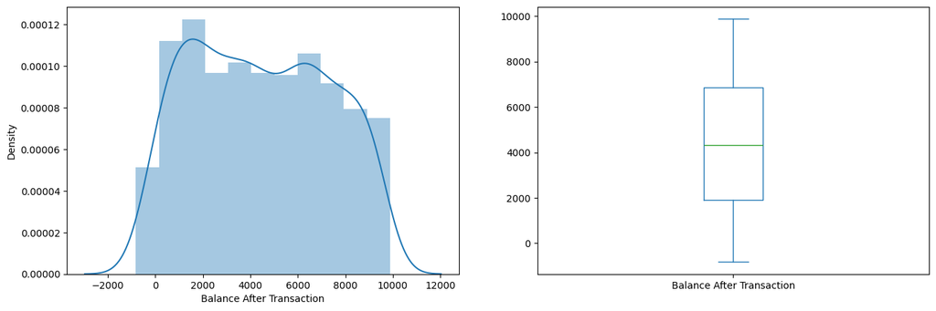

```python
# Let’s check the distribution of Balance After Transaction variable.
plt.figure(1)
plt.subplot(121)
sns.distplot(dataset['Balance After Transaction'], kde=True)

plt.subplot(122)
dataset['Balance After Transaction'].plot.box(figsize=(16,5))

plt.show()
```

- Data distribution for Balance After Transaction column looks normal and no significant skewness found.
- No outliers found for Balance After Transaction column

#### Handling Skewness of data

```python
numerical_features = dataset.select_dtypes(include=["number"]).columns
print("Determining Skewness of numerical data")
print("==="*10)
for i in numerical_features:
    print(f"{i}  : {dataset[i].skew()}")
```

```
Determining Skewness of numerical data
==============================
Amount  : -0.11766475577090117
Previous Transactions  : 0.026361332343532554
Balance Before Transaction  : 0.0791833977696478
Time of Day  : -0.00822899673183438
Velocity  : -0.0066808536347064545
Customer Age  : 0.017007335806539136
Customer Income  : 0.07392843563325675
Card Limit  : -0.05066551963703225
Credit Score  : -0.04077557449292022
Merchant Location History  : 0.04239159049158024
Spending Patterns  : -0.031202151744079004
Is Fraudulent  : 3.9964722093322753
Balance After Transaction  : 0.08927325150897872
```

- There is no siginificant skewness exists in numerical columns.
- The columns Previous Transactions, Balance Before Transaction, Customer Age, Customer Income, Merchant Location History, Balance After Transaction are having positive skewness and others having negative skewness.
- The skewness values are near to zero, so no need for skewness transformations.

#### 3.b.(ii). Transforms data from categorical to numerical using one-hot encoding technique

```python
dataset = pd.get_dummies(dataset)
```

```python
display(dataset)
```

|  | Amount | Previous Transactions | Balance Before Transaction | Time of Day | Velocity | Customer Age | Customer Income | Card Limit | Credit Score | Merchant Location History | ... | Location_US | Device_Desktop | Device_Mobile | Device_POS | Merchant Reputation_Average | Merchant Reputation_Bad | Merchant Reputation_Good | Online Transactions Frequency_High | Online Transactions Frequency_Low | Online Transactions Frequency_Medium |
| --- | --- | --- | --- | --- | --- | --- | --- | --- | --- | --- | --- | --- | --- | --- | --- | --- | --- | --- | --- | --- | --- |
| 0 | 180.924993 | 6 | 919.055267 | 10 | -0.337955 | 52 | 105545.340543 | 2503.758986 | 401 | 6 | ... | False | True | False | False | True | False | False | False | False | True |
| 1 | 794.625797 | 5 | 3529.930762 | 17 | 0.015117 | 62 | 92651.854405 | 12885.681726 | 409 | 13 | ... | False | True | False | False | True | False | False | False | True | False |
| 2 | 818.413303 | 5 | 6578.889931 | 4 | -0.198457 | 42 | 90579.479280 | 2039.105869 | 323 | 1 | ... | False | False | False | True | False | False | True | True | False | False |
| 3 | 530.306522 | 3 | 8036.856328 | 20 | -0.076741 | 76 | 63777.184316 | 5568.880208 | 674 | 1 | ... | True | False | True | False | False | True | False | True | False | False |
| 4 | 649.101853 | 4 | 5342.795887 | 16 | -0.029077 | 39 | 30620.998085 | 6945.439545 | 533 | 3 | ... | False | True | False | False | False | False | True | False | True | False |
| ... | ... | ... | ... | ... | ... | ... | ... | ... | ... | ... | ... | ... | ... | ... | ... | ... | ... | ... | ... | ... | ... |
| 995 | 536.205566 | 6 | 7131.892816 | 0 | 0.428024 | 72 | 54013.284619 | 11581.476660 | 656 | 14 | ... | False | False | True | False | True | False | False | True | False | False |
| 996 | 615.954996 | 8 | 6940.176274 | 14 | 0.430410 | 40 | 140803.006752 | 15882.824558 | 312 | 11 | ... | False | True | False | False | False | True | False | True | False | False |
| 997 | 472.562610 | 4 | 4209.798746 | 9 | 0.477102 | 54 | 52788.254160 | 17589.131736 | 424 | 4 | ... | False | True | False | False | True | False | False | False | True | False |
| 998 | 517.723900 | 8 | 496.330227 | 4 | 0.331765 | 21 | 65820.723836 | 15900.001061 | 529 | 6 | ... | True | False | False | True | False | False | True | False | True | False |
| 999 | 489.865943 | 0 | 4015.643994 | 13 | 0.109080 | 71 | 127303.531382 | 14111.272226 | 542 | 7 | ... | True | True | False | False | True | False | False | False | False | True |

1000 rows × 37 columns

```python
dataset.columns
```

```
Index(['Amount', 'Previous Transactions', 'Balance Before Transaction',
       'Time of Day', 'Velocity', 'Customer Age', 'Customer Income',
       'Card Limit', 'Credit Score', 'Merchant Location History',
       'Spending Patterns', 'Is Fraudulent', 'Balance After Transaction',
       'Card Type_Credit', 'Card Type_Debit', 'Card Type_Prepaid',
       'MCC Category_Clothing', 'MCC Category_Electronics',
       'MCC Category_Entertainment', 'MCC Category_Groceries',
       'MCC Category_Healthcare', 'MCC Category_Restaurants',
       'MCC Category_Travel', 'Location_Canada', 'Location_France',
       'Location_Germany', 'Location_UK', 'Location_US', 'Device_Desktop',
       'Device_Mobile', 'Device_POS', 'Merchant Reputation_Average',
       'Merchant Reputation_Bad', 'Merchant Reputation_Good',
       'Online Transactions Frequency_High',
       'Online Transactions Frequency_Low',
       'Online Transactions Frequency_Medium'],
      dtype='object')
```

## 4. Model Building

### 4.a. Split the dataset into training and test sets

We also need to separate the independent and target variables separately as the scikit implemenations require us to provide data in specific format only.

```python
# Let x is set of independant variables
x = dataset.drop("Is Fraudulent", axis=1).values

# Let y is target variable Is Fraudulent
y = dataset['Is Fraudulent'].values
```

```python
x
```

```
array([[180.9249926706157, 6, 919.0552670906062, ..., False, False, True],
       [794.6257974392151, 5, 3529.930761525718, ..., False, True, False],
       [818.4133029325131, 5, 6578.889930687726, ..., True, False, False],
       ...,
       [472.56261026064914, 4, 4209.798745679666, ..., False, True,
        False],
       [517.7239000854652, 8, 496.3302270186082, ..., False, True, False],
       [489.8659426770615, 0, 4015.643994060624, ..., False, False, True]],
      dtype=object)
```

```python
y
```

```
array([0, 1, 0, 0, 0, 0, 0, 0, 0, 0, 0, 0, 1, 0, 0, 0, 0, 0, 0, 0, 0, 0,
       0, 0, 0, 0, 0, 0, 0, 0, 0, 0, 1, 0, 0, 0, 0, 0, 1, 0, 0, 0, 0, 0,
       0, 0, 0, 0, 0, 0, 0, 0, 0, 0, 0, 0, 0, 0, 0, 0, 0, 0, 0, 0, 0, 0,
       1, 0, 0, 0, 0, 0, 0, 0, 0, 0, 0, 0, 0, 0, 0, 0, 0, 0, 0, 0, 0, 0,
       0, 0, 0, 0, 0, 0, 0, 0, 0, 0, 0, 0, 0, 0, 0, 0, 1, 0, 0, 0, 0, 0,
       0, 0, 0, 0, 0, 0, 0, 0, 0, 0, 0, 0, 0, 0, 0, 0, 0, 0, 0, 0, 0, 0,
       0, 0, 1, 0, 0, 0, 0, 0, 0, 0, 0, 0, 0, 0, 0, 0, 0, 0, 0, 0, 0, 0,
       0, 0, 0, 0, 0, 0, 0, 0, 0, 0, 0, 0, 0, 0, 0, 0, 0, 0, 0, 0, 0, 0,
       0, 0, 0, 0, 0, 0, 0, 0, 0, 0, 0, 0, 0, 1, 0, 0, 0, 1, 1, 0, 0, 0,
       0, 0, 0, 0, 0, 0, 0, 0, 0, 0, 0, 0, 0, 0, 0, 0, 0, 0, 0, 0, 0, 0,
       0, 0, 0, 0, 0, 0, 0, 0, 0, 0, 0, 0, 0, 0, 0, 0, 1, 0, 0, 0, 0, 0,
       0, 0, 0, 1, 0, 0, 1, 0, 1, 0, 0, 0, 0, 0, 0, 0, 0, 0, 0, 0, 0, 0,
       0, 0, 0, 0, 0, 0, 0, 0, 0, 0, 0, 0, 0, 0, 0, 0, 0, 1, 0, 0, 0, 0,
       0, 0, 0, 0, 0, 1, 0, 0, 0, 0, 0, 0, 0, 0, 0, 0, 0, 1, 0, 0, 1, 0,
       0, 0, 0, 0, 0, 0, 0, 0, 1, 0, 0, 0, 0, 0, 1, 0, 0, 0, 0, 0, 0, 0,
```

[output cut: 31 more lines]

```python
# Feature Scaling
from sklearn.preprocessing import StandardScaler
sc = StandardScaler()
x = sc.fit_transform(x)
```

#### Model Training

```python
from sklearn.model_selection import train_test_split
```

#### 4.a.(i). Train = 80 % Test = 20%

```python
x_train, x_test, y_train, y_test = train_test_split(x, y, test_size=0.2)
```

```python
x_train
```

```
array([[-1.19587947,  0.21256799,  0.83671737, ..., -0.6828438 ,
        -0.71614196,  1.38399852],
       [-0.01458613,  0.56625848,  0.95720797, ..., -0.6828438 ,
        -0.71614196,  1.38399852],
       [-0.89379   , -1.20219399,  1.73087936, ...,  1.46446375,
        -0.71614196, -0.72254413],
       ...,
       [ 0.2313308 ,  1.62732996, -1.27668999, ..., -0.6828438 ,
        -0.71614196,  1.38399852],
       [-0.11384227, -0.494813  , -0.32426545, ..., -0.6828438 ,
         1.39637119, -0.72254413],
       [-1.3587696 , -1.55588448,  0.79290169, ..., -0.6828438 ,
         1.39637119, -0.72254413]])
```

```python
y_train
```

```
array([0, 0, 0, 0, 0, 0, 0, 0, 0, 0, 0, 0, 0, 0, 0, 0, 0, 0, 0, 0, 0, 0,
       0, 0, 0, 0, 0, 0, 0, 0, 0, 0, 0, 0, 0, 0, 0, 0, 0, 0, 0, 0, 0, 0,
       0, 0, 0, 0, 0, 0, 0, 0, 0, 0, 0, 1, 0, 0, 0, 0, 0, 0, 0, 1, 0, 0,
       0, 0, 0, 0, 0, 1, 0, 0, 0, 0, 0, 0, 0, 0, 0, 0, 0, 0, 0, 0, 0, 0,
       0, 0, 0, 0, 0, 0, 0, 0, 0, 0, 0, 0, 0, 0, 0, 0, 0, 0, 0, 0, 0, 0,
       0, 0, 0, 0, 0, 0, 0, 0, 0, 0, 1, 0, 0, 1, 0, 0, 0, 0, 0, 0, 0, 0,
       0, 0, 0, 1, 0, 0, 0, 0, 0, 0, 0, 0, 0, 0, 0, 0, 0, 0, 0, 0, 0, 0,
       0, 0, 0, 0, 0, 0, 0, 0, 0, 0, 0, 0, 0, 0, 0, 0, 0, 0, 0, 0, 0, 0,
       0, 0, 0, 1, 0, 0, 0, 1, 1, 0, 1, 1, 0, 0, 0, 0, 0, 0, 0, 0, 0, 0,
       0, 0, 0, 0, 0, 0, 0, 0, 0, 0, 0, 0, 0, 0, 0, 0, 1, 0, 0, 0, 0, 0,
       0, 0, 0, 0, 0, 0, 0, 0, 0, 0, 0, 0, 0, 0, 0, 0, 0, 0, 0, 0, 0, 0,
       0, 0, 0, 0, 0, 0, 0, 0, 0, 0, 0, 0, 0, 0, 1, 0, 0, 0, 0, 0, 0, 0,
       0, 0, 0, 0, 0, 0, 0, 0, 0, 0, 0, 0, 0, 0, 0, 0, 0, 0, 0, 0, 0, 0,
       0, 0, 0, 0, 1, 0, 0, 0, 0, 0, 0, 0, 1, 0, 0, 0, 0, 0, 0, 0, 0, 0,
       0, 0, 0, 0, 0, 0, 0, 0, 0, 0, 0, 0, 0, 0, 0, 0, 0, 0, 0, 0, 0, 0,
```

[output cut: 22 more lines]

### 4.b. Build model using Logistic Regression model

Fitting Logistic Regression to the Training set

```python
# Fitting Logistic Regression to the Training set
from sklearn.linear_model import LogisticRegression
classifier = LogisticRegression(random_state = 0)
classifier.fit(x_train, y_train)
```

```
LogisticRegression(random_state=0)
```

```python
y_predict_train = classifier.predict(x_train)
y_predict_train
```

```
array([0, 0, 0, 0, 0, 0, 0, 0, 0, 0, 0, 0, 0, 0, 0, 0, 0, 0, 0, 0, 0, 0,
       0, 0, 0, 0, 0, 0, 0, 0, 0, 0, 0, 0, 0, 0, 0, 0, 0, 0, 0, 0, 0, 0,
       0, 0, 0, 0, 0, 0, 0, 0, 0, 0, 0, 0, 0, 0, 0, 0, 0, 0, 0, 0, 0, 0,
       0, 0, 0, 0, 0, 0, 0, 0, 0, 0, 0, 0, 0, 0, 0, 0, 0, 0, 0, 0, 0, 0,
       0, 0, 0, 0, 0, 0, 0, 0, 0, 0, 0, 0, 0, 0, 0, 0, 0, 0, 0, 0, 0, 0,
       0, 0, 0, 0, 0, 0, 0, 0, 0, 0, 0, 0, 0, 0, 0, 0, 0, 0, 0, 0, 0, 0,
       0, 0, 0, 0, 0, 0, 0, 0, 0, 0, 0, 0, 0, 0, 0, 0, 0, 0, 0, 0, 0, 0,
       0, 0, 0, 0, 0, 0, 0, 0, 0, 0, 0, 0, 0, 0, 0, 0, 0, 0, 0, 0, 0, 0,
       0, 0, 0, 0, 0, 0, 0, 0, 0, 0, 0, 0, 0, 0, 0, 0, 0, 0, 0, 0, 0, 0,
       0, 0, 0, 0, 0, 0, 0, 0, 0, 0, 0, 0, 0, 0, 0, 0, 0, 0, 0, 0, 0, 0,
       0, 0, 0, 0, 0, 0, 0, 0, 0, 0, 0, 0, 0, 0, 0, 0, 0, 0, 0, 0, 0, 0,
       0, 0, 0, 0, 0, 0, 0, 0, 0, 0, 0, 0, 0, 0, 0, 0, 0, 0, 0, 0, 0, 0,
       0, 0, 0, 0, 0, 0, 0, 0, 0, 0, 0, 0, 0, 0, 0, 0, 0, 0, 0, 0, 0, 0,
       0, 0, 0, 0, 0, 0, 0, 0, 0, 0, 0, 0, 0, 0, 0, 0, 0, 0, 0, 0, 0, 0,
       0, 0, 0, 0, 0, 0, 0, 0, 0, 0, 0, 0, 0, 0, 0, 0, 0, 0, 0, 0, 0, 0,
```

[output cut: 22 more lines]

```python
y_predict_test = classifier.predict(x_test)
y_predict_test
```

```
array([0, 0, 0, 0, 0, 0, 0, 0, 0, 0, 0, 0, 0, 0, 0, 0, 0, 0, 0, 0, 0, 0,
       0, 0, 0, 0, 0, 0, 0, 0, 0, 0, 0, 0, 0, 0, 0, 0, 0, 0, 0, 0, 0, 0,
       0, 0, 0, 0, 0, 0, 0, 0, 0, 0, 0, 0, 0, 0, 0, 0, 0, 0, 0, 0, 0, 0,
       0, 0, 0, 0, 0, 0, 0, 0, 0, 0, 0, 0, 0, 0, 0, 0, 0, 0, 0, 0, 0, 0,
       0, 0, 0, 0, 0, 0, 0, 0, 0, 0, 0, 0, 0, 0, 0, 0, 0, 0, 0, 0, 0, 0,
       0, 0, 0, 0, 0, 0, 0, 0, 0, 0, 0, 0, 0, 0, 0, 0, 0, 0, 0, 0, 0, 0,
       0, 0, 0, 0, 0, 0, 0, 0, 0, 0, 0, 0, 0, 0, 0, 0, 0, 0, 0, 0, 0, 0,
       0, 0, 0, 0, 0, 0, 0, 0, 0, 0, 0, 0, 0, 0, 0, 0, 0, 0, 0, 0, 0, 0,
       0, 0, 0, 0, 0, 0, 0, 0, 0, 0, 0, 0, 0, 0, 0, 0, 0, 0, 0, 0, 0, 0,
       0, 0])
```

Checking the Logistic Regression model metrics with confusion matrix

```
              precision    recall  f1-score   support

           0       0.94      1.00      0.97       188
           1       0.00      0.00      0.00        12

    accuracy                           0.94       200
   macro avg       0.47      0.50      0.48       200
weighted avg       0.88      0.94      0.91       200
```

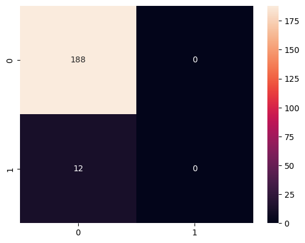

```python
from sklearn.metrics import classification_report, confusion_matrix
cm = confusion_matrix(y_test, y_predict_test)
sns.heatmap(cm, annot=True, fmt="d")
print(classification_report(y_test, y_predict_test))
```

#### Handle Class Imbalance using SMOTE technique

#### Applying Logistic regression with 80, 20 ratio train and test data and also with 70, 30 ratio

```python
from sklearn.datasets import make_classification
from imblearn.over_sampling import SMOTE

# Generate an imbalanced dataset
x, y = make_classification(n_classes=2, class_sep=2, weights=[0.95, 0.05],
                           n_samples=1000, random_state=42)

# Check class distribution before SMOTE
print("Before SMOTE:", dict(pd.Series(y).value_counts()))

# Split data into training and test sets with 80, 20 ratio
x_train, x_test, y_train, y_test = train_test_split(x, y, test_size=0.2, stratify=y, random_state=42)

# 70, 30 ratio of training and test sets
x_train_70, x_test_30, y_train_70, y_test_30 = train_test_split(x, y, test_size=0.3, stratify=y, random_state=42)

# Apply SMOTE on the training set
smote = SMOTE(sampling_strategy='auto', random_state=42)
x_train, y_train = smote.fit_resample(x_train, y_train)
x_train_70, y_train_70 = smote.fit_resample(x_train_70, y_train_70)

# Check class distribution after SMOTE
print("After SMOTE with 80, 20 ratio train and test data:", dict(pd.Series(y_train).value_counts()))
print("After SMOTE with 70, 30 ratio train and test data:", dict(pd.Series(y_train_70).value_counts()))
```

```
Before SMOTE: {0: 947, 1: 53}
After SMOTE with 80, 20 ratio train and test data: {0: 758, 1: 758}
After SMOTE with 70, 30 ratio train and test data: {0: 663, 1: 663}
```

80% Train data of independent variables after applying SMOTE

```python
x_train
```

```
array([[-0.99477172, -0.26999495,  1.27524701, ...,  1.02488643,
         0.52353882, -0.86489611],
       [-1.97932969,  0.02308581, -0.10119763, ...,  0.30017505,
         0.50865149,  0.71833154],
       [ 1.84766   , -0.32349099,  0.6451835 , ..., -1.33582685,
         0.45031694, -0.63452132],
       ...,
       [ 0.24105212, -0.19083825,  0.65321686, ...,  0.11055416,
        -0.99287628, -0.99245719],
       [ 1.62253947, -2.17739001,  1.03058609, ...,  0.90055722,
        -1.87357909, -1.14877825],
       [-1.00427286,  0.62209459,  0.20106656, ...,  0.07569555,
         0.25067581,  0.62542436]])
```

70% Train data of independent variables after applying SMOTE

```python
x_train_70
```

```
array([[ 2.44957093e-01,  1.42742886e+00, -7.56004019e-01, ...,
        -4.55467056e-01,  1.18436506e+00, -4.50253388e-01],
       [ 8.09264698e-01,  1.86377421e+00, -1.26518897e-01, ...,
        -9.02808927e-01,  1.65141027e+00, -5.15170899e-01],
       [ 1.34593501e+00,  2.92588905e+00,  4.67690104e-01, ...,
         6.08267166e-01,  2.77478026e+00, -6.89111798e-01],
       ...,
       [-5.97925314e-01,  1.52626721e+00,  5.35038456e-01, ...,
         1.64671013e+00,  1.21988794e+00, -9.97775308e-01],
       [ 9.36655739e-01,  5.90480607e-04, -3.31750298e-01, ...,
         1.60908645e+00, -3.16324643e-01, -1.32391201e-01],
       [ 1.02357677e+00, -6.23901755e-02, -2.33384151e-01, ...,
         4.04530686e-01, -1.12816307e+00, -9.34348402e-01]])
```

80% Train data of target variables after applying SMOTE

```python
y_train
```

```
array([0, 0, 0, ..., 1, 1, 1])
```

70% Train data of target variables after applying SMOTE

```python
y_train_70
```

```
array([0, 0, 0, ..., 1, 1, 1])
```

Fitting Logistic Regression to the Training set after applying SMOTE

```python
# Fitting Logistic Regression to the Training set
from sklearn.linear_model import LogisticRegression
classifier = LogisticRegression(random_state = 0)
classifier_70_30 = LogisticRegression(random_state = 0)
classifier.fit(x_train, y_train)
```

```
LogisticRegression(random_state=0)
```

Fitting Logistic Regression with 70% train and 30% test dataset

```python
classifier_70_30.fit(x_train_70, y_train_70)
```

```
LogisticRegression(random_state=0)
```

```python
y_predict_train = classifier.predict(x_train)
y_predict_train
```

```
array([0, 0, 0, ..., 1, 1, 1])
```

```python
y_predict_train_70 = classifier_70_30.predict(x_train_70)
y_predict_train_70
```

```
array([0, 0, 0, ..., 0, 1, 1])
```

```python
y_predict_test = classifier.predict(x_test)
y_predict_test
```

```
array([0, 0, 0, 0, 0, 0, 0, 0, 0, 0, 0, 0, 0, 0, 0, 0, 0, 0, 0, 0, 0, 0,
       0, 0, 0, 0, 0, 0, 0, 0, 0, 0, 0, 1, 0, 0, 1, 0, 0, 0, 0, 0, 0, 0,
       0, 0, 0, 0, 0, 1, 0, 0, 0, 0, 1, 1, 0, 0, 0, 0, 1, 0, 0, 0, 0, 0,
       0, 0, 0, 0, 0, 0, 1, 0, 0, 0, 0, 0, 1, 0, 1, 0, 1, 0, 0, 0, 0, 0,
       0, 0, 0, 0, 0, 0, 0, 0, 1, 0, 0, 0, 0, 0, 0, 0, 0, 0, 0, 0, 0, 1,
       0, 0, 0, 0, 0, 0, 0, 0, 0, 0, 0, 0, 0, 0, 0, 0, 0, 0, 0, 0, 0, 0,
       0, 0, 0, 1, 1, 0, 0, 0, 0, 1, 0, 0, 0, 0, 1, 0, 0, 0, 0, 0, 0, 0,
       0, 0, 0, 0, 1, 0, 0, 0, 0, 0, 0, 0, 0, 0, 0, 0, 0, 0, 0, 0, 0, 0,
       0, 0, 0, 1, 0, 0, 0, 0, 0, 0, 0, 0, 1, 0, 0, 0, 0, 0, 0, 0, 0, 0,
       0, 0])
```

```python
y_predict_test_30 = classifier_70_30.predict(x_test_30)
y_predict_test_30
```

```
array([0, 0, 0, 0, 0, 0, 0, 0, 0, 0, 0, 0, 0, 0, 1, 0, 0, 0, 0, 0, 0, 0,
       0, 0, 0, 0, 0, 0, 0, 0, 0, 0, 1, 0, 0, 0, 0, 0, 0, 0, 0, 0, 0, 0,
       0, 0, 0, 0, 0, 1, 1, 0, 0, 0, 0, 0, 0, 0, 0, 0, 0, 0, 0, 0, 0, 0,
       0, 1, 0, 0, 0, 0, 0, 0, 0, 0, 0, 0, 0, 0, 0, 0, 0, 0, 0, 0, 0, 0,
       0, 0, 0, 0, 0, 1, 1, 0, 0, 0, 0, 0, 0, 0, 0, 1, 0, 0, 0, 0, 0, 1,
       0, 0, 0, 0, 0, 0, 0, 0, 0, 0, 0, 0, 0, 0, 0, 0, 0, 0, 1, 0, 0, 0,
       0, 0, 0, 0, 0, 0, 0, 0, 0, 0, 0, 0, 0, 0, 1, 0, 0, 0, 0, 0, 0, 0,
       0, 0, 0, 0, 0, 0, 0, 0, 0, 0, 0, 0, 0, 0, 0, 0, 0, 0, 1, 0, 1, 1,
       0, 0, 1, 0, 0, 0, 0, 0, 0, 0, 0, 1, 0, 0, 0, 0, 0, 0, 1, 0, 0, 0,
       1, 0, 0, 1, 0, 0, 0, 0, 0, 0, 0, 0, 0, 0, 0, 0, 0, 0, 0, 0, 0, 0,
       0, 0, 0, 0, 0, 0, 0, 0, 0, 0, 1, 0, 0, 0, 0, 0, 0, 0, 0, 0, 0, 0,
       0, 0, 0, 0, 0, 0, 0, 0, 0, 0, 0, 0, 0, 1, 0, 0, 0, 0, 0, 0, 0, 0,
       0, 1, 0, 0, 0, 0, 0, 0, 0, 0, 0, 0, 1, 0, 0, 0, 0, 0, 0, 1, 0, 0,
       0, 0, 0, 0, 0, 0, 0, 0, 0, 0, 0, 0, 0, 0])
```

#### Analyzing the Logistic Regression model with confusion matrix after SMOTE applied

```
Logistic Regression Metrics for for 80, 20 ratio
========================================
              precision    recall  f1-score   support

           0       0.99      0.95      0.97       189
           1       0.53      0.91      0.67        11

    accuracy                           0.95       200
   macro avg       0.76      0.93      0.82       200
weighted avg       0.97      0.95      0.96       200

Logistic Regression Metrics for for 70, 30 ratio
========================================
              precision    recall  f1-score   support

           0       0.99      0.96      0.97       284
           1       0.54      0.81      0.65        16

    accuracy                           0.95       300
   macro avg       0.77      0.89      0.81       300
weighted avg       0.97      0.95      0.96       300
```

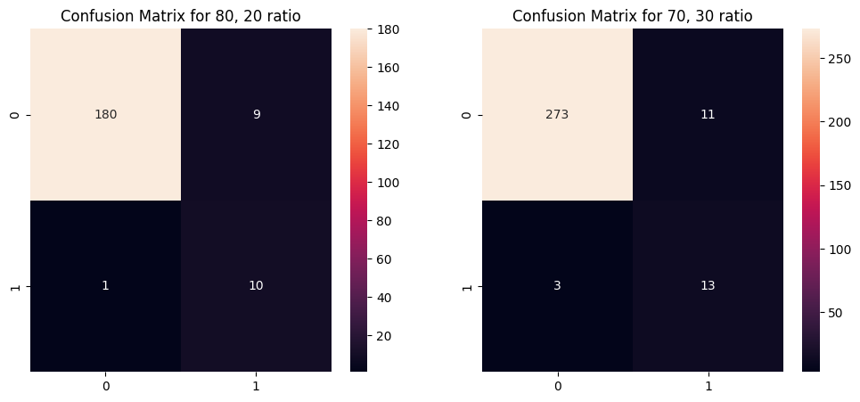

```python
from sklearn.metrics import classification_report, confusion_matrix
cm = confusion_matrix(y_test, y_predict_test)
cm_70_30 = confusion_matrix(y_test_30, y_predict_test_30)
plt.subplots(1, 2, figsize=(12, 5))
plt.subplot(121)
sns.heatmap(cm, annot=True, fmt="d")
plt.title("Confusion Matrix for 80, 20 ratio")
plt.subplot(122)
sns.heatmap(cm_70_30, annot=True, fmt="d")
plt.title("Confusion Matrix for 70, 30 ratio")
print("Logistic Regression Metrics for for 80, 20 ratio")
print("===="*10)
print(classification_report(y_test, y_predict_test))
print("Logistic Regression Metrics for for 70, 30 ratio")
print("===="*10)
print(classification_report(y_test_30, y_predict_test_30))
```

##### Observations:

- Training and test dataset with 70, 30 ratio is showing similar results as 80, 20 ratio except recall of class 1.
- 80, 20 ratio of train and test dataset is giving better recall score in showing the fraud transaction than 70, 30 ratio.

#### Comparing the Logistic Regression with 80, 20 ratio and 70, 30 ratio using ROC curve

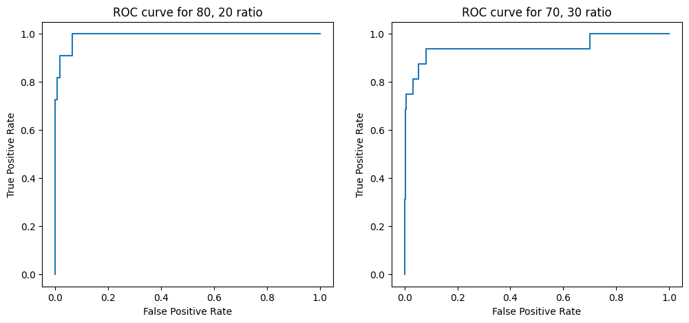

```python
from sklearn import metrics
#define metrics
y_pred_proba =classifier.predict_proba(x_test)[::,1]
y_pred_proba_70_30 =classifier_70_30.predict_proba(x_test_30)[::,1]

fpr, tpr, _ = metrics.roc_curve(y_test,  y_pred_proba)
fpr_70_30, tpr_70_30, _ = metrics.roc_curve(y_test_30,  y_pred_proba_70_30)

#create ROC curve
plt.subplots(1, 2, figsize=(12, 5))
plt.subplot(121)
plt.plot(fpr,tpr)
plt.ylabel('True Positive Rate')
plt.xlabel('False Positive Rate')
plt.title("ROC curve for 80, 20 ratio")
plt.subplot(122)
plt.plot(fpr_70_30,tpr_70_30)
plt.ylabel('True Positive Rate')
plt.xlabel('False Positive Rate')
plt.title("ROC curve for 70, 30 ratio")
plt.show()
```

- 80% train and 20% test split ratio giving better results for Logistic Regression model compared with 70%, 30% train and test dataset.

#### Model Building using Decision Tree

```python
from sklearn.tree import DecisionTreeClassifier
from sklearn.metrics import confusion_matrix
from sklearn.tree import export_graphviz
from six import StringIO
from IPython.display import Image
from pydot import graph_from_dot_data
```

#### Fitting Decision Tree model

Using SMOTE technique, Decision tree is giving poor performance results. So not applied SMOTE for decision tree.

```python
dt = DecisionTreeClassifier(random_state=100)
#Train and Test dataset with 80% and 20% ratio
x_dt_train, x_dt_test, y_dt_train, y_dt_test = train_test_split(x, y, test_size=0.2)
dt.fit(x_dt_train, y_dt_train)
```

```
DecisionTreeClassifier(random_state=100)
```

Checking the dataset columns

```python
dataset.columns
```

```
Index(['Amount', 'Previous Transactions', 'Balance Before Transaction',
       'Time of Day', 'Velocity', 'Customer Age', 'Customer Income',
       'Card Limit', 'Credit Score', 'Merchant Location History',
       'Spending Patterns', 'Is Fraudulent', 'Balance After Transaction',
       'Card Type_Credit', 'Card Type_Debit', 'Card Type_Prepaid',
       'MCC Category_Clothing', 'MCC Category_Electronics',
       'MCC Category_Entertainment', 'MCC Category_Groceries',
       'MCC Category_Healthcare', 'MCC Category_Restaurants',
       'MCC Category_Travel', 'Location_Canada', 'Location_France',
       'Location_Germany', 'Location_UK', 'Location_US', 'Device_Desktop',
       'Device_Mobile', 'Device_POS', 'Merchant Reputation_Average',
       'Merchant Reputation_Bad', 'Merchant Reputation_Good',
       'Online Transactions Frequency_High',
       'Online Transactions Frequency_Low',
       'Online Transactions Frequency_Medium'],
      dtype='object')
```

Training the data with decision tree model

```python
y_dt_predict_train = dt.predict(x_dt_train)
y_dt_predict_train
```

```
array([0, 0, 0, 0, 0, 0, 0, 0, 0, 0, 0, 0, 0, 0, 0, 0, 0, 0, 0, 0, 1, 0,
       0, 0, 0, 0, 0, 1, 0, 0, 0, 0, 0, 0, 0, 0, 0, 0, 0, 0, 0, 0, 1, 0,
       0, 0, 1, 0, 0, 0, 0, 0, 0, 0, 0, 0, 0, 0, 0, 0, 0, 1, 0, 0, 0, 0,
       0, 0, 0, 0, 0, 0, 0, 0, 0, 0, 0, 0, 0, 0, 0, 0, 0, 0, 0, 0, 1, 1,
       0, 0, 0, 0, 0, 0, 0, 0, 0, 0, 0, 0, 0, 0, 0, 0, 0, 0, 0, 0, 0, 0,
       0, 0, 0, 0, 0, 0, 0, 0, 0, 0, 0, 0, 0, 1, 0, 0, 0, 0, 0, 0, 0, 0,
       1, 0, 0, 0, 1, 0, 0, 0, 0, 0, 0, 0, 0, 0, 0, 0, 0, 0, 0, 0, 0, 0,
       0, 0, 0, 0, 0, 0, 0, 0, 0, 0, 0, 0, 0, 0, 0, 0, 0, 0, 0, 0, 0, 0,
       0, 0, 0, 0, 0, 0, 0, 0, 0, 0, 0, 0, 0, 0, 0, 0, 0, 1, 0, 0, 0, 0,
       1, 0, 0, 0, 0, 0, 0, 0, 0, 0, 0, 0, 0, 1, 0, 0, 0, 0, 0, 0, 0, 0,
       0, 0, 0, 0, 0, 0, 0, 0, 0, 0, 0, 0, 0, 1, 0, 0, 0, 0, 0, 0, 0, 0,
       0, 0, 0, 0, 0, 0, 1, 0, 0, 0, 0, 0, 0, 0, 0, 0, 0, 0, 1, 0, 0, 0,
       0, 0, 1, 0, 0, 0, 1, 0, 0, 0, 0, 0, 0, 0, 0, 0, 0, 0, 0, 0, 0, 0,
       0, 0, 1, 0, 0, 0, 0, 0, 0, 0, 0, 0, 0, 0, 0, 0, 0, 0, 0, 0, 0, 0,
       0, 0, 0, 0, 1, 0, 0, 0, 0, 0, 0, 0, 0, 0, 0, 0, 0, 0, 0, 0, 0, 0,
```

[output cut: 22 more lines]

```python
y_dt_predict_test = dt.predict(x_dt_test)
y_dt_predict_test
```

```
array([0, 0, 0, 0, 0, 0, 0, 0, 0, 0, 0, 0, 0, 0, 0, 0, 0, 0, 0, 0, 1, 0,
       0, 0, 0, 0, 0, 0, 0, 0, 0, 0, 0, 0, 0, 0, 0, 0, 0, 0, 0, 0, 0, 0,
       0, 0, 0, 0, 0, 0, 0, 0, 0, 0, 0, 0, 0, 0, 0, 0, 0, 0, 0, 0, 0, 1,
       0, 0, 0, 0, 0, 0, 0, 0, 0, 0, 0, 0, 0, 0, 0, 0, 0, 0, 0, 0, 0, 0,
       0, 0, 0, 0, 0, 0, 0, 0, 0, 0, 0, 0, 0, 0, 0, 0, 0, 0, 0, 0, 1, 0,
       0, 0, 0, 0, 0, 0, 0, 0, 0, 0, 0, 0, 0, 0, 0, 0, 0, 0, 0, 0, 0, 0,
       0, 0, 0, 1, 0, 0, 0, 0, 0, 0, 0, 1, 0, 0, 0, 0, 0, 0, 0, 0, 0, 1,
       0, 0, 0, 0, 0, 1, 0, 0, 0, 0, 0, 0, 0, 0, 0, 0, 0, 0, 0, 0, 0, 0,
       0, 0, 0, 0, 0, 0, 0, 0, 0, 0, 0, 0, 0, 1, 1, 0, 0, 0, 0, 0, 0, 0,
       0, 0])
```

#### Evaluating decision tree with confusion matrix metrics

```
              precision    recall  f1-score   support

           0       0.99      0.98      0.99       192
           1       0.67      0.75      0.71         8

    accuracy                           0.97       200
   macro avg       0.83      0.87      0.85       200
weighted avg       0.98      0.97      0.98       200
```

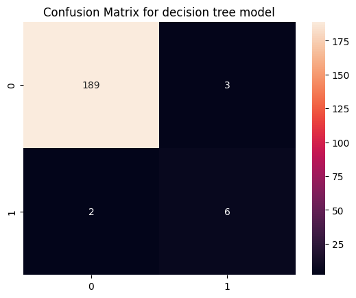

```python
print(classification_report(y_dt_test, y_dt_predict_test))
cm_dt = confusion_matrix(y_dt_test, y_dt_predict_test)
sns.heatmap(cm_dt, annot=True, fmt="d")
plt.title("Confusion Matrix for decision tree model")
```

#### Hyperparameter tuning for Decision Tree

```python
# Hyperparameter tuning for Decision Tree
from sklearn.model_selection import GridSearchCV

param_grid = {
    "max_depth": [3, 5, 10, None],
    "min_samples_split": [2, 5, 10],
    "min_samples_leaf": [1, 2, 4],
    "class_weight": ["balanced"],
}

grid_search = GridSearchCV(DecisionTreeClassifier(random_state=42), param_grid, scoring="recall", cv=5, n_jobs=-1)
grid_search.fit(x_dt_train, y_dt_train)

# Best parameters and retraining best model
best_params = grid_search.best_params_
best_tree_model = DecisionTreeClassifier(**best_params, random_state=42)
best_tree_model.fit(x_dt_train, y_dt_train)

y_pred_best_tree = best_tree_model.predict(x_dt_test)
best_tree_report = classification_report(y_dt_test, y_pred_best_tree)

# Print model performance
print("Best Decision Tree Parameters:", best_params)
print("Decision Tree Report (After Tuning):\n", best_tree_report)
```

```
Best Decision Tree Parameters: {'class_weight': 'balanced', 'max_depth': 3, 'min_samples_leaf': 1, 'min_samples_split': 2}
Decision Tree Report (After Tuning):
               precision    recall  f1-score   support

           0       0.99      0.95      0.97       192
           1       0.44      0.88      0.58         8

    accuracy                           0.95       200
   macro avg       0.72      0.91      0.78       200
weighted avg       0.97      0.95      0.96       200
```

#### Observations:-

- After tuning the hyperparameters, the decision tree metrics have different results.
- Accuracy and F1 scores are decreased.
- While recall for class 1 is good score, it may be misleading the predictions.
- Precision score for class 1 is also decreased a lot.
- So, not using the hyperparameters tuning for decision tree model.

Plotting the visualaizations for decision tree model

[output not shown]

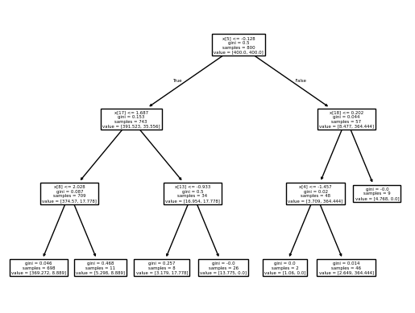

```python
#visualizing tree structure
from sklearn import tree
tree.plot_tree(best_tree_model)
```

```python
#visualizing decision tree using graphviz library
import graphviz
graph_data=tree.export_graphviz(best_tree_model, out_file=None)
graph=graphviz.Source(graph_data)
graph
```

[figure not shown]

## 5. Performance Evaluation

#### 5.a. Compare the performance of the Logistic Regression and Decision Tree models using appropriate evaluation metrics

```
Logistic Regression Report:
              precision    recall  f1-score   support

           0       0.99      0.95      0.97       189
           1       0.53      0.91      0.67        11

    accuracy                           0.95       200
   macro avg       0.76      0.93      0.82       200
weighted avg       0.97      0.95      0.96       200


Decision Tree Report:
              precision    recall  f1-score   support

           0       0.99      0.98      0.99       192
           1       0.67      0.75      0.71         8

    accuracy                           0.97       200
   macro avg       0.83      0.87      0.85       200
weighted avg       0.98      0.97      0.98       200
```

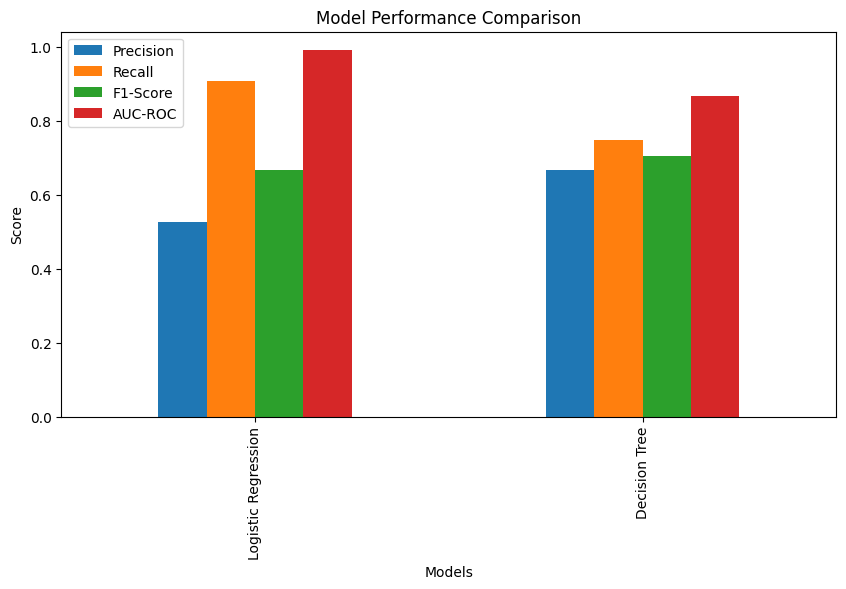

```python
# Display evaluation reports
from sklearn.metrics import classification_report, roc_auc_score, roc_curve, precision_score, recall_score, f1_score
reports = {
    "Logistic Regression": classification_report(y_test, y_predict_test),
    "Decision Tree": classification_report(y_dt_test, y_dt_predict_test),
}
metrics = {
    "Logistic Regression": {"Precision": precision_score(y_test, y_predict_test),
            "Recall": recall_score(y_test, y_predict_test),
            "F1-Score": f1_score(y_test, y_predict_test)},
    "Decision Tree": {"Precision": precision_score(y_dt_test, y_dt_predict_test),
            "Recall": recall_score(y_dt_test, y_dt_predict_test),
            "F1-Score": f1_score(y_dt_test, y_dt_predict_test)},
}
auc_roc_scores = {
    "Logistic Regression": roc_auc_score(y_test, classifier.predict_proba(x_test)[:, 1]),
    "Decision Tree": roc_auc_score(y_dt_test, dt.predict_proba(x_dt_test)[:, 1]),
}
for model, report in reports.items():
    print(f"{model} Report:\n{report}\n")

# Create performance comparison chart
metric_df = pd.DataFrame(metrics).T
metric_df["AUC-ROC"] = auc_roc_scores.values()

plt.figure(figsize=(10, 6))
metric_df.plot(kind="bar", figsize=(10, 5))
plt.title("Model Performance Comparison")
plt.xlabel("Models")
plt.ylabel("Score")
plt.legend(loc="best")
plt.show()
```

#### 5.b. Insights into which model performs better and why

##### Observations:

##### Accuracy:

- Decision tree model is giving higher accuracy compared to Logistic regression model.

##### Precision, Recall, F1 scores

- Decision Tree giving better precision for minority class
- Logistic Regression is giving better recall for minority class which is very important
- Decision Tree overall slightly better F1-score comapred to Logistic model

##### Comparison for Fraud Class (1):

- Logistic Regression is giving higher recall score against Decision Tree

##### Which Model is Better?

- Even though the Decision Tree has better accuracy overall, Logistic Regression is the better choice for fraud detection because it captures more fraud cases.

# Assignment part 2

### Implementing the predictive models and classifiers

#### Implemented Logistic regression and Decision tree classifiers as part of Assignment part 1.

#### Using Ensemble learning method - Random Forest Algorithm

```python
# Random Forest (Bagging Technique)
from sklearn.ensemble import RandomForestClassifier
from sklearn.metrics import confusion_matrix, ConfusionMatrixDisplay

# Train a Random Forest model
rf_model = RandomForestClassifier(n_estimators=100, random_state=42)
rf_model.fit(x_train, y_train)
rf_predictions = rf_model.predict(x_test)
rd_report = classification_report(y_test, rf_predictions)

# Print model performance
print("Random Forest Report:\n", rd_report)
```

```
Random Forest Report:
               precision    recall  f1-score   support

           0       1.00      0.98      0.99       189
           1       0.73      1.00      0.85        11

    accuracy                           0.98       200
   macro avg       0.87      0.99      0.92       200
weighted avg       0.99      0.98      0.98       200
```

##### Plotting the confusion matrix for Random Forest

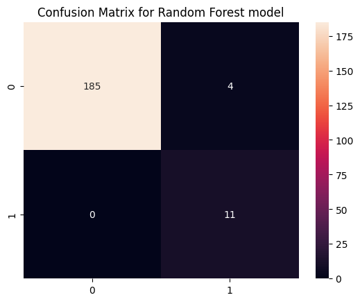

```python
cm_rd = confusion_matrix(y_test, rf_predictions)
sns.heatmap(cm_rd, annot=True, fmt="d")
plt.title("Confusion Matrix for Random Forest model")
```

##### Key Observations:

- Accuracy score is 0.98 which is a better score than Logistic and Decision tree models.
- Recall for class 1 is very high indicating that the fraud transacation is detected with 100% recall rate.
- Precision for class 0 is very high indicating that it can confidence level of identifying the legit transacations.
- F1 scores for both the classes are high.

#### Using Ensemble learning method - AdaBoost Algorithm

```python
# AdaBoost (Boosting Technique)
from sklearn.ensemble import AdaBoostClassifier

# Train an AdaBoost model
ada_model = AdaBoostClassifier(n_estimators=100, random_state=42)
ada_model.fit(x_train, y_train)
ada_predictions = ada_model.predict(x_test)
ada_report = classification_report(y_test, ada_predictions)

# Print model performance
print("AdaBoost Report:\n", ada_report)
```

```
AdaBoost Report:
               precision    recall  f1-score   support

           0       1.00      0.97      0.99       189
           1       0.69      1.00      0.81        11

    accuracy                           0.97       200
   macro avg       0.84      0.99      0.90       200
weighted avg       0.98      0.97      0.98       200
```

##### Plotting the confusion matrix for AdaBoost algorithm

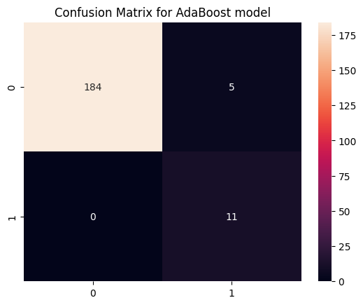

```python
cm_ad = confusion_matrix(y_test, ada_predictions)
sns.heatmap(cm_ad, annot=True, fmt="d")
plt.title("Confusion Matrix for AdaBoost model")
```

#### Using K-Nearest Neighbour Algorithm

```python
# K-Nearest Neighbour Algorithm
from sklearn.neighbors import KNeighborsClassifier

# Train KNN model with 3 nearest neighbours
knn_model = KNeighborsClassifier(n_neighbors=2)
knn_model.fit(x_train, y_train)
knn_predictions = knn_model.predict(x_test)
knn_report = classification_report(y_test, knn_predictions)

# Print model performance
print("K-Nearest Neighbour Report:\n", knn_report)
```

```
K-Nearest Neighbour Report:
               precision    recall  f1-score   support

           0       0.99      0.98      0.99       189
           1       0.71      0.91      0.80        11

    accuracy                           0.97       200
   macro avg       0.85      0.94      0.89       200
weighted avg       0.98      0.97      0.98       200
```

##### Plotting the confusion matrix for KNN algorithm

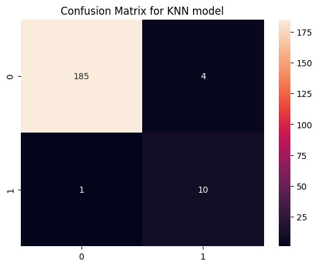

```python
cm_knn = confusion_matrix(y_test, knn_predictions)
sns.heatmap(cm_knn, annot=True, fmt="d")
plt.title("Confusion Matrix for KNN model")
```

### Performance evaluation

```
Logistic Regression Report:
              precision    recall  f1-score   support

           0       0.99      0.95      0.97       189
           1       0.53      0.91      0.67        11

    accuracy                           0.95       200
   macro avg       0.76      0.93      0.82       200
weighted avg       0.97      0.95      0.96       200


==============================
Decision Tree Report:
              precision    recall  f1-score   support

           0       0.99      0.98      0.99       192
           1       0.67      0.75      0.71         8

    accuracy                           0.97       200
   macro avg       0.83      0.87      0.85       200
weighted avg       0.98      0.97      0.98       200


==============================
Random Forest Report:
              precision    recall  f1-score   support

           0       1.00      0.98      0.99       189
           1       0.73      1.00      0.85        11

    accuracy                           0.98       200
   macro avg       0.87      0.99      0.92       200
weighted avg       0.99      0.98      0.98       200


==============================
AdaBoost Report:
              precision    recall  f1-score   support

           0       1.00      0.97      0.99       189
           1       0.69      1.00      0.81        11

    accuracy                           0.97       200
   macro avg       0.84      0.99      0.90       200
weighted avg       0.98      0.97      0.98       200


==============================
KNN Report:
              precision    recall  f1-score   support

           0       0.99      0.98      0.99       189
           1       0.71      0.91      0.80        11

    accuracy                           0.97       200
   macro avg       0.85      0.94      0.89       200
weighted avg       0.98      0.97      0.98       200


==============================
```

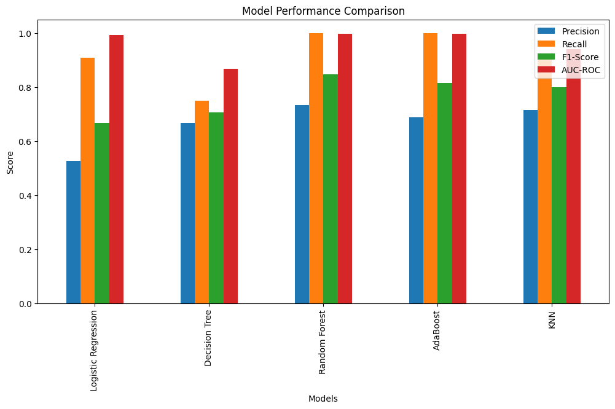

```python
# Display evaluation reports
from sklearn.metrics import classification_report, roc_auc_score, roc_curve, precision_score, recall_score, f1_score
reports = {
    "Logistic Regression": classification_report(y_test, y_predict_test),
    "Decision Tree": classification_report(y_dt_test, y_dt_predict_test),
    "Random Forest": classification_report(y_test, rf_predictions),
    "AdaBoost": classification_report(y_test, ada_predictions),
    "KNN": classification_report(y_test, knn_predictions),
}
metrics = {
    "Logistic Regression": {"Precision": precision_score(y_test, y_predict_test),
            "Recall": recall_score(y_test, y_predict_test),
            "F1-Score": f1_score(y_test, y_predict_test)},
    "Decision Tree": {"Precision": precision_score(y_dt_test, y_dt_predict_test),
            "Recall": recall_score(y_dt_test, y_dt_predict_test),
            "F1-Score": f1_score(y_dt_test, y_dt_predict_test)},
    "Random Forest": {"Precision": precision_score(y_test, rf_predictions),
            "Recall": recall_score(y_test, rf_predictions),
            "F1-Score": f1_score(y_test, rf_predictions)},
    "AdaBoost": {"Precision": precision_score(y_test, ada_predictions),
            "Recall": recall_score(y_test, ada_predictions),
            "F1-Score": f1_score(y_test, ada_predictions)},
    "KNN": {"Precision": precision_score(y_test, knn_predictions),
            "Recall": recall_score(y_test, knn_predictions),
            "F1-Score": f1_score(y_test, knn_predictions)},
}
auc_roc_scores = {
    "Logistic Regression": roc_auc_score(y_test, classifier.predict_proba(x_test)[:, 1]),
    "Decision Tree": roc_auc_score(y_dt_test, dt.predict_proba(x_dt_test)[:, 1]),
    "Random Forest": roc_auc_score(y_test, rf_model.predict_proba(x_test)[:, 1]),
    "AdaBoost": roc_auc_score(y_test, ada_model.predict_proba(x_test)[:, 1]),
    "KNN": roc_auc_score(y_test, knn_model.predict_proba(x_test)[:, 1]),
}
for model, report in reports.items():
    print(f"{model} Report:\n{report}\n")
    print("==="*10)

# Create performance comparison chart
metric_df = pd.DataFrame(metrics).T
metric_df["AUC-ROC"] = auc_roc_scores.values()

plt.figure(figsize=(10, 6))
metric_df.plot(kind="bar", figsize=(12, 6))
plt.title("Model Performance Comparison")
plt.xlabel("Models")
plt.ylabel("Score")
plt.legend(loc="best")
plt.show()
```

### Comparing Models with more Performance Evaluation Metrics

#### Considering the below metrics for comparing and evaluating the models

```python
from sklearn.metrics import (accuracy_score, precision_score, recall_score, f1_score, confusion_matrix, roc_curve, auc, roc_auc_score, r2_score)
# Determining Performance Evaluation Metrics
def compute_metrics(y_t, y_p, y_prob):
    tn, fp, fn, tp = confusion_matrix(y_t, y_p).ravel()

    accuracy = accuracy_score(y_t, y_p)
    precision = precision_score(y_t, y_p)
    recall = recall_score(y_t, y_p)
    f1 = f1_score(y_t, y_p)

    # True Positive Rate (TPR) = Recall
    tpr = recall
    # False Positive Rate (FPR)
    fpr = fp / (fp + tn)
    # True Negative Rate (TNR) = Specificity
    tnr = tn / (tn + fp)
    # False Negative Rate (FNR)
    fnr = fn / (fn + tp)
    # ROC AUC Score
    roc_auc = roc_auc_score(y_t, y_prob)
    # Adjusted R² (for completeness)
    r2 = r2_score(y_t, y_p)

    return [accuracy, precision, recall, f1, tpr, fpr, tnr, fnr, roc_auc, r2]

# Create DataFrame for comparison
metrics = ["Accuracy", "Precision", "Recall (TPR)", "F1-Score", "TPR", "FPR", "TNR", "FNR", "ROC AUC", "Adjusted R²"]
log_metrics = compute_metrics(y_test, y_predict_test, classifier.predict_proba(x_test)[:, 1])
tree_metrics = compute_metrics(y_dt_test, y_dt_predict_test, dt.predict_proba(x_dt_test)[:, 1])
rf_metrics = compute_metrics(y_test, rf_predictions, rf_model.predict_proba(x_test)[:, 1])
ada_metrics = compute_metrics(y_test, ada_predictions, ada_model.predict_proba(x_test)[:, 1])
knn_metrics = compute_metrics(y_test, knn_predictions, knn_model.predict_proba(x_test)[:, 1])

df_metrics = pd.DataFrame({"Metric": metrics,
                           "Logistic Regression": log_metrics,
                           "Decision Tree": tree_metrics,
                           "Random Forest": rf_metrics,
                           "AdaBoost": ada_metrics,
                           "KNN": knn_metrics
                           })

# Display Results
print(df_metrics)
```

```
         Metric  Logistic Regression  Decision Tree  Random Forest  AdaBoost  \
0      Accuracy             0.950000       0.975000       0.980000  0.975000
1     Precision             0.526316       0.666667       0.733333  0.687500
2  Recall (TPR)             0.909091       0.750000       1.000000  1.000000
3      F1-Score             0.666667       0.705882       0.846154  0.814815
4           TPR             0.909091       0.750000       1.000000  1.000000
5           FPR             0.047619       0.015625       0.021164  0.026455
6           TNR             0.952381       0.984375       0.978836  0.973545
7           FNR             0.090909       0.250000       0.000000  0.000000
8       ROC AUC             0.992304       0.867188       0.996633  0.997114
9   Adjusted R²             0.037999       0.348958       0.615200  0.519000

        KNN
0  0.975000
1  0.714286
2  0.909091
3  0.800000
4  0.909091
5  0.021164
6  0.978836
7  0.090909
8  0.941318
9  0.519000
```

##### Plot ROC Curve for comparision of models performance

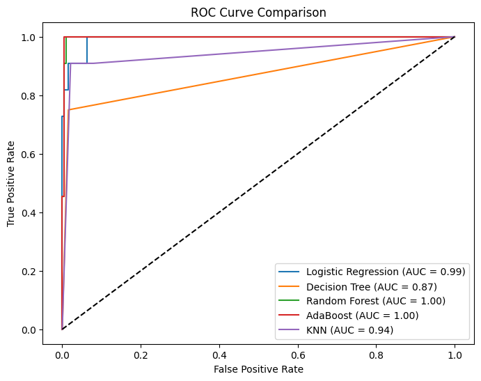

```python
# Plot ROC Curve
plt.figure(figsize=(8, 6))
fpr_log, tpr_log, _ = roc_curve(y_test, classifier.predict_proba(x_test)[:, 1])
fpr_tree, tpr_tree, _ = roc_curve(y_dt_test, dt.predict_proba(x_dt_test)[:, 1])
fpr_rf, tpr_rf, _ = roc_curve(y_test, rf_model.predict_proba(x_test)[:, 1])
fpr_ada, tpr_ada, _ = roc_curve(y_test, ada_model.predict_proba(x_test)[:, 1])
fpr_knn, tpr_knn, _ = roc_curve(y_test, knn_model.predict_proba(x_test)[:, 1])

plt.plot(fpr_log, tpr_log, label=f'Logistic Regression (AUC = {roc_auc_score(y_test, classifier.predict_proba(x_test)[:, 1]):.2f})')
plt.plot(fpr_tree, tpr_tree, label=f'Decision Tree (AUC = {roc_auc_score(y_dt_test, dt.predict_proba(x_dt_test)[:, 1]):.2f})')
plt.plot(fpr_rf, tpr_rf, label=f'Random Forest (AUC = {roc_auc_score(y_test, rf_model.predict_proba(x_test)[:, 1]):.2f})')
plt.plot(fpr_ada, tpr_ada, label=f'AdaBoost (AUC = {roc_auc_score(y_test, ada_model.predict_proba(x_test)[:, 1]):.2f})')
plt.plot(fpr_knn, tpr_knn, label=f'KNN (AUC = {roc_auc_score(y_test, knn_model.predict_proba(x_test)[:, 1]):.2f})')

plt.plot([0, 1], [0, 1], 'k--')
plt.xlabel("False Positive Rate")
plt.ylabel("True Positive Rate")
plt.title("ROC Curve Comparison")
plt.legend()
plt.show()
```

##### Create performance comparison chart

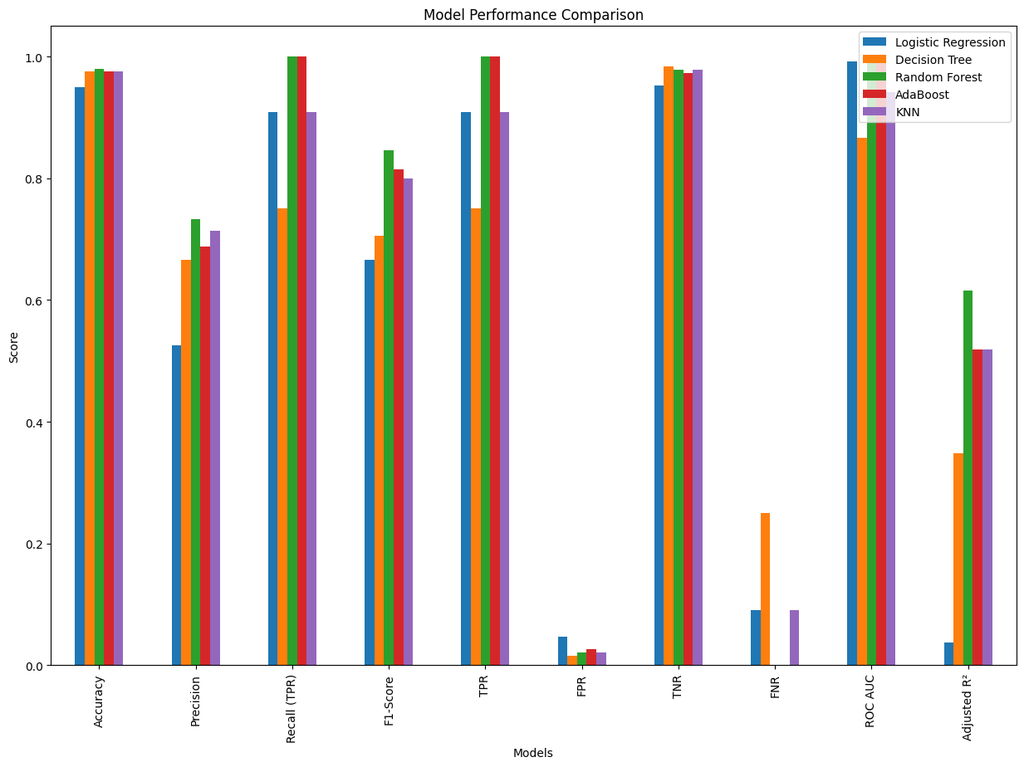

```python
# Create performance comparison chart
df_metrics = df_metrics.set_index('Metric')
plt.figure(figsize=(10, 6))
df_metrics.plot(kind="bar", figsize=(15, 10))
plt.title("Model Performance Comparison")
plt.xlabel("Models")
plt.ylabel("Score")
plt.legend(loc="best")
plt.show()
```

### Analyzing the model performances

While AdaBoost also has strong performance, its precision (0.6875) is lower than Random Forest's (0.7333), indicating that it misclassifies more negative instances as positives.

Thus, **Random Forest is the best model due to its high accuracy, near-perfect recall, strong precision, and an excellent AUC score**.